# Homework 2

# Homework 2

## setting up the environment

- install most up to date ISLR, not really necessary every time
- load the ISLR library
- loading the help documentation for the college data set
- loading the raw data set inline

```r
# install.packages("ISLR")
library(ISLR)
help(College)
College
```

[output not shown]

[output cut: 767 more lines]

```r
library(tidyverse)
library(ggplot2)
```

## 1

#### A

- Input 𝑋: Often multidimensional, in which each dimension is referred to as a feature, predictor, or independent variable
- Output 𝑌: The response or dependent variable

#### B

- use `lm()` to find the simple linear regression model?
- `lm(formula, data, ...)` where the formula looks like Y~X, data is an optional argument
- $β_0$ and $β_1$ are two unknown constants that represent the intercept and slope terms in the linear model. Together, β0 and β1 are known as the model coefficients or parameters.
- These $𝛽_0$ (Intercept) and $𝛽_1$ (Top10perc) are those that minimize RSS and yield the **least squares regression line**.

```r
lm.fit = lm(formula = Outstate ~ Top10perc, data = College)
lm.fit
```

```
Call:
lm(formula = Outstate ~ Top10perc, data = College)

Coefficients:
(Intercept)    Top10perc
     6906.5        128.2
```

#### D

- confidence intervals for $B_0$ and $B_1$

```r
confint(lm.fit, level = 0.95)
```

```
                2.5 %    97.5 %
(Intercept) 6471.4241 7341.4931
Top10perc    114.9459  141.5415
```

#### E

- point estimate
- the `c()` is “combine,” it is creating a list of the x values

```r
lm.pointEst = predict(lm.fit, data.frame(Top10perc = c(0.33)))
lm.pointEst
```

```
       1
6948.779
```

```r
confint(lm.pointEst, level = 0.95)
```

```
Error: $ operator is invalid for atomic vectors
```

#### F

- plotting lm.fit using geom_jitter() and geom_smooth()

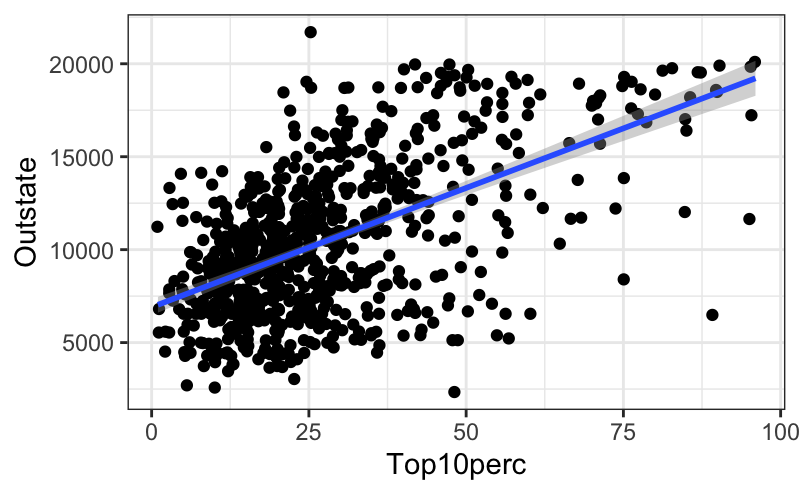

```r
ggplot(data = lm.fit, mapping = aes(x=Top10perc, y=Outstate)) + geom_jitter() + geom_smooth(method='lm', formula= y~x) + theme_bw()
```

## 2

#### A

- The null hypothesis 𝐇𝟎 is a specific statement about a population parameter that is made for the purposes of argument. A good null hypothesis is something that would be interesting to reject, and thus is uninteresting. (slide 102 in LR p1)
- The alternative hypothesis 𝐇𝐀 includes all possible values for the population parameter aside from the one stated by the null hypothesis. The alternative hypothesis is what the researcher hopes is true, and thus is interesting. (slide 103 in LR p1)

#### B

- We can view all of the output of lm() with the summary() function using `summary()`
- test statistic

```r
summary(lm.fit)
```

```
Call:
lm(formula = Outstate ~ Top10perc, data = College)

Residuals:
     Min       1Q   Median       3Q      Max
-11831.1  -2418.4    211.1   2116.4  11587.4

Coefficients:
            Estimate Std. Error t value
(Intercept) 6906.459    221.614   31.16
Top10perc    128.244      6.774   18.93
            Pr(>|t|)
(Intercept)   <2e-16 ***
Top10perc     <2e-16 ***
---
Signif. codes:
0 ‘***’ 0.001 ‘**’ 0.01 ‘*’ 0.05 ‘.’ 0.1 ‘ ’ 1

Residual standard error: 3329 on 775 degrees of freedom
Multiple R-squared:  0.3162,    Adjusted R-squared:  0.3153
F-statistic: 358.4 on 1 and 775 DF,  p-value: < 2.2e-16
```

- p value: < 2.2e-16

## 3

#### A

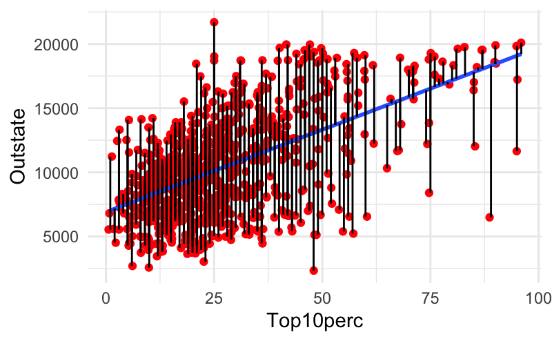

```r
ggplot(data = lm.fit,, mapping = aes(x=Top10perc, y=Outstate)) + geom_jitter(color = "red") + geom_smooth(method='lm', formula= y~x, level = 0) + geom_segment(mapping = aes(xend=Top10perc, yend=.fitted)) + theme_minimal()
```